# TERRE GRS: Non-genetic factors sensitivity analysis

The manuscript “A Parkinson’s disease genetic risk score associates with blood DNAm on chromosome 17” explores how a genetic risk score (GRS) for Parkinson’s disease (PD) associates with blood DNA methylation in the TERRE study of French agricultural workers, and evaluates GRS associations with DNAm in each sex as well as their sensitivity to non-genetic factors. This was originally spearheaded by Will Casazza and was posted as a pre-print on medRxiv in 2023. The current revision (2024, led by Sam Schaffner) aims to address previous reviewer feedback and prepare the manuscript for re-submission.

Last updated June 9, 2025 by Samantha Schaffner: Pulling full list of SNP x E interaction stats

Based on code by Will Casazza

### Loading in and preparing data

```r
meta <- read.csv("~/PD_GRS/meta_geno_DNAm_PCs.csv")

# DNAm data (2022, most recent QC'ed, same as npj PD 2024 article)
load("~/SHARE_DECIPHER/processed_DNAm_data/2022/TERRE_processed_2022/1-TERRE_RG_filtered.RData")
mvals <- getM(PD_RG_filtered)
rm(PD_RG_filtered)

## Preparing data
# match meta data and M-values
meta <- meta[complete.cases(meta$CTP_PC1),]
mvals <- mvals[,match(meta$patient, colnames(mvals))]
all(colnames(mvals)==meta$patient) #TRUE

# subset meta data to relevant columns and re-format
meta_sub <- meta[,c("patient","SCORE1_AVG","PD","age","sex","geno_V3","geno_V4","geno_V5","CTP_PC1","CTP_PC2","CTP_PC3","CTP_PC4","CTP_PC5","CTP_PC6","smoking","pesticides","head_trauma","alcohol1","levodopa","agonist","plate","SentrixPosition_A")]
str(meta_sub)
meta_sub$PD <- as.factor(meta_sub$PD)
meta_sub$sex <- as.factor(meta_sub$sex)
meta_sub$smoking <- as.factor(meta_sub$smoking)
meta_sub$pesticides <- as.factor(meta_sub$pesticides)
meta_sub$head_trauma <- as.factor(meta_sub$head_trauma)
meta_sub$alcohol1 <- as.factor(meta_sub$alcohol1)
meta_sub$levodopa <- as.factor(meta_sub$levodopa)
meta_sub$plate <- as.factor(meta_sub$plate)
meta_sub$SentrixPosition_A <- as.factor(meta_sub$SentrixPosition_A)
```

# Association analyses

Will used limma on all EPIC probes passing QC, modeling the data with M-values. I’ll continue with this approach and transform results back to beta values later for plotting and interpretation purposes.

## Smoking, alcohol, head trauma, and overall pesticide exposure

```r
# check meta data for missing values
summary(meta_sub) #20 missing pesticides, otherwise complete

# adjustment for smoking
design_smoke <- model.matrix(~ 1 + SCORE1_AVG + age + sex + geno_V3 + geno_V4 + geno_V5 + CTP_PC1 + CTP_PC2 + CTP_PC3 + CTP_PC4 + CTP_PC5 + CTP_PC6 + plate + SentrixPosition_A + PD + smoking, data = meta_sub)
smoke_fit <- lmFit(mvals, design_smoke)
smoke_fit <- eBayes(smoke_fit)
smoke_fit_coef <- smoke_fit$coefficients
m0_eff <- smoke_fit_coef[, "(Intercept)"] #M-value model intercept
m1_eff <- m0_eff + smoke_fit_coef[, "SCORE1_AVG"] #M-value model intercept plus GRS coefficient (delta M)
smoke_res <- limma::topTable(smoke_fit, coef = 2, number = Inf, genelist=rownames(mvals))
smoke_res$adjDB <- m2beta(m1_eff) - m2beta(m0_eff)
nrow(smoke_res[abs(smoke_res$adjDB)>=0.03 & smoke_res$adj.P.Val<=0.05,]) #22
write.csv(smoke_res, file="~/PD_GRS/non_genetic_sensitivity/EWAS_GRS_smoke.csv", row.names=F)

# adjustment for head trauma
design_ht <- model.matrix(~ 1 + SCORE1_AVG + age + sex + geno_V3 + geno_V4 + geno_V5 + CTP_PC1 + CTP_PC2 + CTP_PC3 + CTP_PC4 + CTP_PC5 + CTP_PC6 + plate + SentrixPosition_A + PD + head_trauma, data = meta_sub)
ht_fit <- lmFit(mvals, design_ht)
ht_fit <- eBayes(ht_fit)
ht_fit_coef <- ht_fit$coefficients
m0_eff <- ht_fit_coef[, "(Intercept)"] #M-value model intercept
m1_eff <- m0_eff + ht_fit_coef[, "SCORE1_AVG"] #M-value model intercept plus GRS coefficient (delta M)
ht_res <- limma::topTable(ht_fit, coef = 2, number = Inf, genelist=rownames(mvals))
ht_res$adjDB <- m2beta(m1_eff) - m2beta(m0_eff)
nrow(ht_res[abs(ht_res$adjDB)>=0.03 & ht_res$adj.P.Val<=0.05,]) #23
write.csv(ht_res, file="~/PD_GRS/non_genetic_sensitivity/EWAS_GRS_ht.csv", row.names=F)

# adjustment for alcohol
design_alc <- model.matrix(~ 1 + SCORE1_AVG + age + sex + geno_V3 + geno_V4 + geno_V5 + CTP_PC1 + CTP_PC2 + CTP_PC3 + CTP_PC4 + CTP_PC5 + CTP_PC6 + plate + SentrixPosition_A + PD + alcohol1, data = meta_sub)
alc_fit <- lmFit(mvals, design_alc)
alc_fit <- eBayes(alc_fit)
alc_fit_coef <- alc_fit$coefficients
m0_eff <- alc_fit_coef[, "(Intercept)"] #M-value model intercept
m1_eff <- m0_eff + alc_fit_coef[, "SCORE1_AVG"] #M-value model intercept plus GRS coefficient (delta M)
alc_res <- limma::topTable(alc_fit, coef = 2, number = Inf, genelist=rownames(mvals))
alc_res$adjDB <- m2beta(m1_eff) - m2beta(m0_eff)
nrow(alc_res[abs(alc_res$adjDB)>=0.03 & alc_res$adj.P.Val<=0.05,]) #24
write.csv(alc_res, file="~/PD_GRS/non_genetic_sensitivity/EWAS_GRS_alc.csv", row.names=F)

# adjustment for overall pesticide exposure
meta_pest <- meta_sub[complete.cases(meta_sub$pesticides),]
summary(meta_pest$PD)
#  0   1
#135  63
mvals_pest <- mvals[,match(meta_pest$patient, colnames(mvals))]
design_pest <- model.matrix(~ 1 + SCORE1_AVG + age + sex + geno_V3 + geno_V4 + geno_V5 + CTP_PC1 + CTP_PC2 + CTP_PC3 + CTP_PC4 + CTP_PC5 + CTP_PC6 + plate + SentrixPosition_A + PD + pesticides, data = meta_pest)
pest_fit <- lmFit(mvals_pest, design_pest)
pest_fit <- eBayes(pest_fit)
pest_fit_coef <- pest_fit$coefficients
m0_eff <- pest_fit_coef[, "(Intercept)"] #M-value model intercept
m1_eff <- m0_eff + pest_fit_coef[, "SCORE1_AVG"] #M-value model intercept plus GRS coefficient (delta M)
pest_res <- limma::topTable(pest_fit, coef = 2, number = Inf, genelist=rownames(mvals))
pest_res$adjDB <- m2beta(m1_eff) - m2beta(m0_eff)
nrow(pest_res[abs(pest_res$adjDB)>=0.03 & pest_res$adj.P.Val<=0.05,]) #16
write.csv(pest_res, file="~/PD_GRS/non_genetic_sensitivity/EWAS_GRS_pest.csv", row.names=F)
```

### Compare results with initial GRS EWAS

```r
grs_res <- read.csv("~/PD_GRS/EWAS_TERRE/EWAS_GRS_cross_sex_hits.csv")

nrow(smoke_hits <- smoke_res[abs(smoke_res$adjDB)>=0.03 & smoke_res$adj.P.Val<=0.05,]) #22
nrow(ht_hits <- ht_res[abs(ht_res$adjDB)>=0.03 & ht_res$adj.P.Val<=0.05,]) #23
nrow(alc_hits <- alc_res[abs(alc_res$adjDB)>=0.03 & alc_res$adj.P.Val<=0.05,]) #24
nrow(pest_hits <- pest_res[abs(pest_res$adjDB)>=0.03 & pest_res$adj.P.Val<=0.05,]) #16

#summarize overlaps
length(all_probes <- unique(c(grs_res$TargetID, smoke_hits$ID, ht_hits$ID, alc_hits$ID, pest_hits$ID))) #28 unique probes
all_data <- data.frame(TargetID=all_probes, GRS=(all_probes %in% grs_res$TargetID), GRS_smoking=(all_probes %in% smoke_hits$ID), GRS_head_trauma=(all_probes %in% ht_hits$ID), GRS_alcohol=(all_probes %in% alc_hits$ID), GRS_pesticides=(all_probes %in% pest_hits$ID))
sensitivity <- left_join(grs_res[,c("TargetID","UCSC_REFGENE_NAME","UCSC_REFGENE_GROUP","adjDB","adj.P.Val")], all_data[,c(1,3:6)], by="TargetID")
write.csv(sensitivity, file="~/PD_GRS/non_genetic_sensitivity/sensitivity_overlaps.csv", row.names=FALSE)

#upset plot
all_data[,2:6] <- apply(all_data[,2:6], 2, function(x) as.numeric(x))
upset(all_data, sets=c("GRS","GRS_smoking","GRS_head_trauma","GRS_alcohol","GRS_pesticides"),order.by="degree")
```

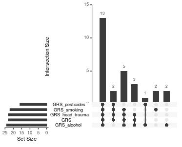

Overlap between probes significant in sensitivity analyses and original EWAS

## PD medications

We have data for levodopa and dopamine agonist (yes/no) as well as levodopa equivalent daily dose. This time, run sensitivity analysis within PD cases with adjustment for these variables.

```r
# check meta data
str(meta_sub)
meta_sub$agonist <- as.factor(meta_sub$agonist)
meta_PD <- meta_sub[meta_sub$PD==1,]
table(meta_PD$levodopa, meta_PD$agonist)
#     0  1
#  0  2 16
#  1 16 37

mvals_PD <- mvals[,match(meta_PD$patient, colnames(mvals))]

# adjustment for levodopa
design_levo <- model.matrix(~ 1 + SCORE1_AVG + age + sex + geno_V3 + geno_V4 + geno_V5 + CTP_PC1 + CTP_PC2 + CTP_PC3 + CTP_PC4 + CTP_PC5 + CTP_PC6 + plate + SentrixPosition_A + levodopa, data = meta_PD)
levo_fit <- lmFit(mvals_PD, design_levo)
levo_fit <- eBayes(levo_fit)
levo_res <- limma::topTable(levo_fit, coef = 2, number = Inf, genelist=rownames(mvals_PD))
write.csv(levo_res, file="~/PD_GRS/non_genetic_sensitivity/EWAS_GRS_levo.csv", row.names=F)

# adjustment for levodopa equivalent daily dose
led <- read.csv("~/PD_CMRs_GxE/3-posthoc/levodopa/levodopa_corrected.csv")
all(meta_PD$patient %in% led$NUM) #FALSE
nrow(meta_PD[meta_PD$patient %in% led$NUM,]) #42 PD cases with LED information
meta_led <- meta_PD[meta_PD$patient %in% led$NUM,]
colnames(led)[1] <- "patient"
meta_led <- left_join(meta_led, led, by="patient")
str(meta_led$led_levodopa) #numeric - OK
mvals_led <- mvals_PD[,match(meta_led$patient, colnames(mvals_PD))]

design_led <- model.matrix(~ 1 + SCORE1_AVG + age + sex + geno_V3 + geno_V4 + geno_V5 + CTP_PC1 + CTP_PC2 + CTP_PC3 + CTP_PC4 + CTP_PC5 + CTP_PC6 + plate + SentrixPosition_A + led_levodopa, data = meta_led)
led_fit <- lmFit(mvals_led, design_led)
led_fit <- eBayes(led_fit)
led_res <- limma::topTable(led_fit, coef = 2, number = Inf, genelist=rownames(mvals_led))
write.csv(led_res, file="~/PD_GRS/non_genetic_sensitivity/EWAS_GRS_led.csv", row.names=F)

# adjustment for dopamine agonist
design_agonist <- model.matrix(~ 1 + SCORE1_AVG + age + sex + geno_V3 + geno_V4 + geno_V5 + CTP_PC1 + CTP_PC2 + CTP_PC3 + CTP_PC4 + CTP_PC5 + CTP_PC6 + plate + SentrixPosition_A + agonist, data = meta_PD)
agonist_fit <- lmFit(mvals_PD, design_agonist)
agonist_fit <- eBayes(agonist_fit)
agonist_res <- limma::topTable(agonist_fit, coef = 2, number = Inf, genelist=rownames(mvals_PD))
write.csv(agonist_res, file="~/PD_GRS/non_genetic_sensitivity/EWAS_GRS_agonist.csv", row.names=F)
```

### Compare results with initial GRS EWAS in PD cases

There were no hits in the case-only EWAS (CpGs did not reach statistical signficance). Still, check the top CpGs here.

```r
grs_cases <- read.csv("~/PD_GRS/EWAS_TERRE/EWAS_GRS_cases.csv")
min(grs_cases$adj.P.Val)
#[1] 0.9999635
min(grs_cases$P.Value)
#[1] 9.693712e-06
nrow(grs_nom <- grs_cases[grs_cases$P.Value<=1e-4 & abs(grs_cases$delta_M)>=1.5,]) #27

nrow(levo_hits <- levo_res[abs(levo_res$logFC)>=1.5 & levo_res$P.Value<=1e-4,]) #21
min(levo_hits$adj.P.Val) #[1] 0.9895193
nrow(led_hits <- led_res[abs(led_res$logFC)>=1.5 & led_res$P.Value<=1e-4,]) #40
min(led_hits$adj.P.Val) #[1] 0.8035613
nrow(agonist_hits <- agonist_res[abs(agonist_res$logFC)>=1.5 & agonist_res$P.Value<=1e-4,]) #21
min(agonist_hits$adj.P.Val) #[1] 0.9999963

#summarize overlaps
all_probes <- unique(c(grs_nom$TargetID, levo_hits$ID, led_hits$ID, agonist_hits$ID)) #81 unique probes
all_data <- data.frame(TargetID=all_probes, GRS=(all_probes %in% grs_nom$TargetID), GRS_levo=(all_probes %in% levo_hits$ID), GRS_led=(all_probes %in% led_hits$ID), GRS_agonist=(all_probes %in% agonist_hits$ID))
sensitivity <- left_join(grs_nom[,c("TargetID","UCSC_REFGENE_NAME","UCSC_REFGENE_GROUP","delta_M","adj.P.Val")], all_data[,c(1,3:5)], by="TargetID")
write.csv(sensitivity, file="~/PD_GRS/non_genetic_sensitivity/sensitivity_overlaps_meds.csv", row.names=FALSE)

#upset plot
all_data[,2:5] <- apply(all_data[,2:5], 2, function(x) as.numeric(x))
upset(all_data, sets=c("GRS","GRS_levo","GRS_led","GRS_agonist"),order.by="degree")
```

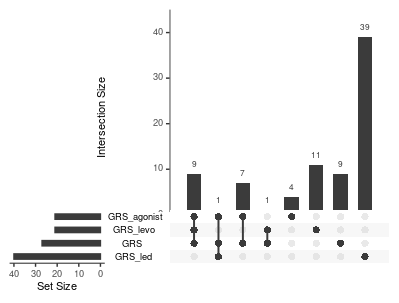

Overlap between probes nominally significant in medication sensitivity analyses and original EWAS in PD cases

9 probes were nominally significant in the case-only analysis and analyses adjusted for levodopa or dopamine agonist (categorical). Surprisingly, the LED-adjusted analysis revealed 39 probes not discovered in the initial GRS EWAS in PD cases nor in the other medication-based sensitivity analyses. However, these were still not significant after multiple test correction.

## Individual pesticide exposures

EWAS will be conducted 10 times for each exposure (once per imputation), then results will be pooled with the “mice” package. Reference: “prs_pest_mice.Rmd” (Will’s original script).

```r
# read in individual imputed pesticides data
pest_imp <- read.csv("~/SHARE_DECIPHER/TERRE_pesticides/pesticides_imputed.csv")

# subset to TERRE early disease duration data set
pest_imp <- pest_imp[pest_imp$num %in% meta_sub$patient,]
length(unique(pest_imp$num)) #186 individuals with imputed pesticide data

# summarize pesticides with at least 10% exposed on average over all imputations
# NOTE, for npj PD paper this was required within each sex; here, looking cross-sex
perc_exp <- colSums(pest_imp[3:ncol(pest_imp)],na.rm=TRUE)
perc_exp <- data.frame(pesticide=names(perc_exp),num_exp_10_imp=perc_exp)
perc_exp$avg_exp_10_imp <- perc_exp$num_exp_10_imp/10
perc_exp$perc_exp_10_imp <- (perc_exp$avg_exp_10_imp/186)*100
summary(perc_exp)
#  pesticide         num_exp_10_imp   avg_exp_10_imp   perc_exp_10_imp
# Length:74          Min.   :  0.00   Min.   : 0.000   Min.   : 0.000
# Class :character   1st Qu.: 37.75   1st Qu.: 3.775   1st Qu.: 2.030
# Mode  :character   Median :136.50   Median :13.650   Median : 7.339
#                    Mean   :207.62   Mean   :20.762   Mean   :11.162
#                    3rd Qu.:319.75   3rd Qu.:31.975   3rd Qu.:17.191
#                    Max.   :773.00   Max.   :77.300   Max.   :41.559
write.csv(perc_exp, file="~/PD_GRS/pest_imp_summary.csv", row.names=F)

nrow(perc_exp <- perc_exp[perc_exp$perc_exp_10_imp>=10,]) # 30 pesticides with >10% exposed
perc_exp$pesticide
# [1] "ins"          "fong"         "herb"         "s"            "cu"           "i_ochl"       "i_oph"
# [8] "i_carb"       "i_pyr"        "f_carb"       "h_phenol"     "h_phyto"      "h_pico"       "h_triazine"
#[15] "h_amides"     "h_uree"       "h_quat"       "h_glyphos"    "i_ddt"        "i_lindane"    "f_dithiocarb"
#[22] "f_carb0"      "h_phenolbis"  "h_ureebis"    "tot_carb"     "tot_uree"     "tot_amide"    "tot_triazine"
#[29] "tot_phenol"   "gardening"

# prepare mice input
pest_imp <- pest_imp[,c("X_imputation_","num",perc_exp$pesticide)]
pest_missing <- read.csv("~/SHARE_DECIPHER/TERRE_pesticides/pesticides.csv")
pest_missing <- pest_missing[pest_missing$num %in% meta_sub$patient,c("num",perc_exp$pesticide)]
all(pest_imp$num[1:186]==pest_missing$num) #TRUE
all(colnames(pest_imp[2:ncol(pest_imp)])==colnames(pest_missing)) #TRUE
mvals_pest <- mvals[,match(pest_missing$num,colnames(mvals))]

pre_mids <-rbind(cbind(data.frame(X_imputation_=0),pest_missing)[,colnames(pest_imp)],pest_imp)
pre_mids <- pre_mids[pre_mids$num %in% colnames(mvals_pest),]
pest_mids <- as.mids(pre_mids, .imp="X_imputation_",.id="num")
terre_pest_meta <- meta_sub[match(rownames(pest_mids$data),meta_sub$patient),]
mvals_pest <- mvals_pest[,rownames(pest_mids$data)]
exposures <- colnames(pest_mids$data)

# took 6 days to run 10 EWAS x 30 pesticides and pool results = 300 EWAS!
for(exposure in exposures){
  print(paste("EWAS with adjustment for", exposure, sep=" "))
  ewas <- mclapply(1:nrow(mvals_pest), function(x){
    fit.cpg <- substitute(pest_mids %>% with(lm(mvals_pest[x,] ~ SCORE1_AVG + age + sex + geno_V3 + geno_V4 + geno_V5 + CTP_PC1 + CTP_PC2 + CTP_PC3 + CTP_PC4 + CTP_PC5 + CTP_PC6 + plate + SentrixPosition_A + PD + E, data=terre_pest_meta)),
                          list(E=as.name(exposure)))
    fit.cpg <- eval(fit.cpg, list(E=as.name(exposure)))
    est.cpg <- pool(fit.cpg)
    return(summary(est.cpg)[2,])
    }, mc.cores=10)
  res <- cbind(do.call(rbind, ewas), probe=rownames(mvals_pest))
  fwrite(res,paste0(exposure,"_pest_imp_sensitivity.txt"),sep="\t",row.names = F,quote=F)}
```

### Compare results with initial GRS EWAS

Checking how many probes still come up as associated with the GRS when each pesticide is adjusted for.

```r
grs_res <- read.csv("~/PD_GRS/EWAS_TERRE/EWAS_GRS_cross_sex_hits.csv")
exp_df <- lapply(1:30, function(x){
  exposures[x] <- rep(FALSE,23)
})
exp_df <- do.call(cbind, exp_df)
colnames(exp_df) <- exposures

grs_pest <- cbind(grs_res[,c("TargetID","delta_M","adj.P.Val","CHR","MAPINFO","UCSC_REFGENE_NAME","UCSC_REFGENE_GROUP")],exp_df)

for(exposure in exposures){
  print(paste("Summarizing results for", exposure, sep=" "))
  res <- fread(paste("~/PD_GRS/non_genetic_sensitivity/exposure_EWAS/", exposure, "_pest_imp_sensitivity.txt",sep=""))
  res$adj.P.Val <- p.adjust(res$p.value, method="BH")
  res$sig <- (res$adj.P.Val<=0.05 & abs(res$estimate)>=1.5)
  for(x in 1:nrow(res)){
    if(res$sig[x]==TRUE){ grs_pest[grs_pest$TargetID==res$probe[x],exposure] <- TRUE }
  }
}

write.csv(grs_pest, file="~/PD_GRS/non_genetic_sensitivity/sensitivity_overlaps_pest.csv", row.names=F)

#summarize overlaps
all_data <- data.frame(GRS=TRUE,ins=grs_pest$ins, fung=grs_pest$fong, herb=grs_pest$herb, s=grs_pest$s, cu=grs_pest$cu, i_ochl=grs_pest$i_ochl, i_oph=grs_pest$i_oph, i_carb=grs_pest$i_carb, i_pyr=grs_pest$i_pyr, f_carb=grs_pest$f_carb, h_phenol=grs_pest$h_phenol, h_phyto=grs_pest$h_phyto, h_pico=grs_pest$h_pico, h_triazine=grs_pest$h_triazine, h_amides=grs_pest$h_amides, h_uree=grs_pest$h_uree, h_quat=grs_pest$h_quat, h_glyphos=grs_pest$h_glyphos, i_ddt=grs_pest$i_ddt, i_lindane=grs_pest$i_lindane, f_dithiocarb=grs_pest$f_dithiocarb, f_carb0=grs_pest$f_carb0, h_phenolbis=grs_pest$h_phenolbis, h_ureebis=grs_pest$h_ureebis, tot_carb=grs_pest$tot_carb, tot_uree=grs_pest$tot_uree, tot_amide=grs_pest$tot_amide, tot_triazine=grs_pest$tot_triazine, tot_phenol=grs_pest$tot_phenol, gardening=grs_pest$gardening)

#upset plot
all_data[] <- apply(all_data[], 2, function(x) as.numeric(x))
upset(all_data, sets=names(all_data),order.by="degree", mb.ratio=c(0.3,0.7))
```

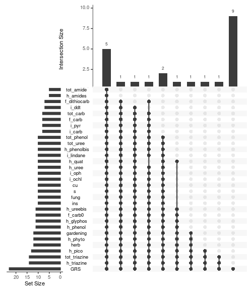

Overlap between probes significant in individual pesticide sensitivity analyses and original EWAS

5 probes were insensitive to adjusting for any pesticide exposure, 9 probes were sensitive to all exposures tested, and 9 probes were sensitive to a combination of exposures. Most probes were sensitive to adjustment for amides, dithiocarbamates, and insecticides.

## Evaluate probes across all non-genetic factors tested

```r
sensitivity <- read.csv("~/PD_GRS/non_genetic_sensitivity/sensitivity_overlaps.csv")
colnames(sensitivity)
sens_all <- left_join(sensitivity, grs_pest, by=c("TargetID","UCSC_REFGENE_NAME","UCSC_REFGENE_GROUP","adj.P.Val"))
write.csv(sens_all, file="~/PD_GRS/non_genetic_sensitivity/sensitivity_all_non_genetic.csv", row.names=F)
```

# Test SNP x E interaction for GRS SNPs that are mQTL

Added May 18, 2025. Updated June 9, 2025. This pulls the 8 SNPs referenced in “7-repl_CpGs_posthoc.Rmd” from the GRS which are mQTL for CpGs associated with the overall GRS score, and tests their interaction with the environmental factors above.

## In combined case-control data

### Prepare genotype data, DNAm data, and meta data

```r
# Get list of 8 SNPs
mqtl_sig <- read.csv("~/PD_GRS/posthoc/mqtl_terre_sig_anno.csv")
length(unique(mqtl_sig$snp)) #8
terre_snps <- unique(mqtl_sig$snp)

# Meta data with SNP genotype
meta_geno <- read.csv("~/PD_GRS/meta_geno_GRS_SNPs.csv")
cols <- c(colnames(meta_geno)[1:168],terre_snps)
meta_geno_sub <- meta_geno[,cols]

# DNAm data (2022, most recent QC'ed, same as npj PD 2024 article)
load("~/SHARE_DECIPHER/processed_DNAm_data/2022/TERRE_processed_2022/1-TERRE_RG_filtered.RData")
mvals <- getM(PD_RG_filtered)

# subset to 11 replicated CpGs
repl_cpgs <- read.csv("~/PD_GRS/TERRE_cross_sex_in_DIGPD_B.csv")
repl_cpgs <- repl_cpgs[repl_cpgs$direction==TRUE,]
dim(mvals <- mvals[rownames(mvals) %in% repl_cpgs$TargetID,colnames(mvals)%in%meta_geno_sub$patient]) #[1]  11 218

# subset meta data to relevant columns and re-format
meta_geno_sub$PD <- as.factor(meta_geno_sub$PD)
meta_geno_sub$sex <- as.factor(meta_geno_sub$sex)
meta_geno_sub$smoking <- as.factor(meta_geno_sub$smoking)
meta_geno_sub$pesticides <- as.factor(meta_geno_sub$pesticides)
meta_geno_sub$head_trauma <- as.factor(meta_geno_sub$head_trauma)
meta_geno_sub$alcohol1 <- as.factor(meta_geno_sub$alcohol1)
meta_geno_sub$levodopa <- as.factor(meta_geno_sub$levodopa)
meta_geno_sub$plate <- as.factor(meta_geno_sub$plate)
meta_geno_sub$SentrixPosition_A <- as.factor(meta_geno_sub$SentrixPosition_A)

# match meta data and M-values
meta_geno_sub <- meta_geno_sub[complete.cases(meta_geno_sub$CTP_PC1),]
mvals <- mvals[,match(meta_geno_sub$patient, colnames(mvals))]
all(colnames(mvals)==meta_geno_sub$patient) #TRUE
```